# Trindidad Fish Predation

Faith Jones

12 June 2017

I decided to just use the summer data so i could incude the 2016 data.I also removed data from 2010

```r
library(dplyr)
library(tidyr)
library(ggplot2)
library(lme4)


setwd("C:\\Users\\faj\\Documents\\OneDrive for Business\\research\\FishPredation\\Data")

fishDataAll <- read.csv("Fish data June 2017.csv")

selectMonths <- c("07", "08")# i am selecting out these months because then i can use the last timepoint


#select data from only the July and Auguest, and remove first year
SelectData <- fishDataAll %>%
    separate(date, c("Day", "Month", "Year"), sep = "/") %>%
    filter(Year != 2010)%>%
    filter(Month %in% selectMonths)

fishData <- data.frame(SelectData)

#calculate biomass
fishData$TotBiomass <- (fishData$numbercaught + fishData$numberseen)* fishData$weight


#calculating percentage abundance
TotBioSite<- fishData %>%
    group_by(site, Year) %>%
    summarise(BiomasSiteSum = sum(TotBiomass, na.rm=TRUE))

siteBiomass <- data.frame(TotBioSite)
```

## Biomass variability in predators initial analysis

```r
#sum biomass per site and year
predatorsBioN <- fishData %>%
    filter(species == "Hoplias malabaricus" | species == "Crenicichla frenata") %>%
    group_by(site, Year) %>%
    summarise(BiomassSum = sum(TotBiomass))

predatorsBio <- data.frame(predatorsBioN)
predatorsBio$Year <- as.numeric(predatorsBio$Year)
siteBiomass$Year <- as.numeric(siteBiomass$Year)

FishDataTot <- merge(siteBiomass, predatorsBio, by = c("site" ,"Year"),all=TRUE) # this makes sure i
#know what years had no predators recoreded in
head(FishDataTot)
```

```
##      site Year BiomasSiteSum BiomassSum
## 1 Acono d 2011       1572.66       99.7
## 2 Acono d 2012        870.00      188.4
## 3 Acono d 2013       1599.30       55.0
## 4 Acono d 2014       1589.12      148.0
## 5 Acono d 2015       1253.90      135.0
## 6 Acono d 2016       1900.55      202.0
```

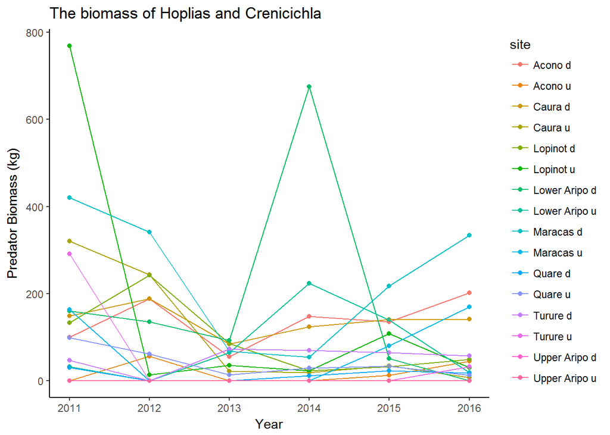

```r
FishDataTot$BiomassSum[is.na(FishDataTot$BiomassSum)] <- 0

#add mean centered year for further analysis
meanYear <-summarise(FishDataTot, meanYear = mean(Year))
FishDataTot$meanYear <- meanYear[1,]
FishDataTot$meanCentredYear <-  FishDataTot$Year - FishDataTot$meanYear

BioPlot <- ggplot(FishDataTot, aes(x = Year, y = BiomassSum, col = site, group = site))
BioPlot + geom_point() +
    geom_line() +
    theme_classic() +
    labs(title="The biomass of Hoplias and Crenicichla", y = "Predator Biomass (kg)")
```

I then took a look at the coefficients of variation between sites and between years

```r
#variation between sites
cvSitesb <- FishDataTot %>%
  group_by(site) %>%
  summarise(meanSite = mean(BiomassSum), sdSite = sd(BiomassSum))%>%
  mutate(cvSite = sdSite/meanSite)
cvSitesBio <- data.frame(cvSitesb)
print(cvSitesBio)
```

```
##             site  meanSite    sdSite    cvSite
## 1        Acono d 138.01667  54.95643 0.3981869
## 2        Acono u  19.08333  25.30300 1.3259212
## 3        Caura d 138.00000  33.75932 0.2446328
## 4        Caura u 107.43333 137.31521 1.2781434
## 5      Lopinot d  94.30000  83.22307 0.8825352
## 6      Lopinot u 163.18333 298.74940 1.8307592
## 7  Lower Aripo d 185.91667 246.44829 1.3255847
## 8  Lower Aripo u  80.13333  85.91826 1.0721912
## 9      Maracas d 239.25000 152.43712 0.6371457
## 10     Maracas u  68.98333  81.98903 1.1885340
## 11       Quare d  13.88333  12.31753 0.8872174
## 12       Quare u  41.63333  33.06942 0.7943016
## 13      Turure d  51.95000  27.11264 0.5218987
## 14      Turure u  53.83333 116.89040 2.1713388
## 15 Upper Aripo d   0.00000   0.00000       NaN
## 16 Upper Aripo u   0.00000   0.00000       NaN
```

```r
#variation between years
cvYearb <- FishDataTot %>%
  group_by(Year) %>%
  summarise(meanYear = mean(BiomassSum), sdYear = sd(BiomassSum))%>%
  mutate(cvSite = sdYear/meanYear)
cvYearBio <- data.frame(cvYearb)
print(cvYearBio)
```

```
##   Year  meanYear    sdYear    cvSite
## 1 2011 169.71875 201.76730 1.1888333
## 2 2012  91.95000 114.22976 1.2423030
## 3 2013  37.08750  36.46827 0.9833035
## 4 2014  87.59375 169.43103 1.9342822
## 5 2015  67.12500  64.33156 0.9583846
## 6 2016  69.87500  94.44778 1.3516677
```

Finally i put together a mixed model of predator biomass against year with site as a random variable, to see how much of the variation in the mean values coudl be explainedby site differences. I am not sure this is the right way to go though. You can see from teh results that sites is accounting for quite a bit of variation, but other residual sources of variation far more important. Site only explains 15% of the underlying variation in the model.

```r
##try a mixed model for biomass
#-------------------------------
bioM1 <- lmer(BiomassSum ~ meanCentredYear + (1|site), data = FishDataTot)
summary(bioM1)
```

```
## Linear mixed model fit by REML ['lmerMod']
## Formula: BiomassSum ~ meanCentredYear + (1 | site)
##    Data: FishDataTot
##
## REML criterion at convergence: 1185.6
##
## Scaled residuals:
##     Min      1Q  Median      3Q     Max
## -1.1485 -0.5278 -0.2201  0.1722  5.1091
##
## Random effects:
##  Groups   Name        Variance Std.Dev.
##  site     (Intercept)  2621     51.2
##  Residual             13990    118.3
## Number of obs: 96, groups:  site, 16
##
## Fixed effects:
##                 Estimate Std. Error t value
## (Intercept)       87.225     17.595   4.957
## meanCentredYear  -14.948      7.069  -2.115
##
## Correlation of Fixed Effects:
##             (Intr)
## meanCntrdYr 0.000
```

I then took a look at log biomass. Site then explains a lot more variation - nearly 50%. Still the sites are not consistantly high or low pressure.

```r
FishDataTot$LogBio <- log2(FishDataTot$BiomassSum + 1)

##try a mixed model for biomass
#-------------------------------
bioM2 <- lmer(LogBio ~ meanCentredYear + (1|site), data = FishDataTot)
summary(bioM2)
```

```
## Linear mixed model fit by REML ['lmerMod']
## Formula: LogBio ~ meanCentredYear + (1 | site)
##    Data: FishDataTot
##
## REML criterion at convergence: 456.4
##
## Scaled residuals:
##      Min       1Q   Median       3Q      Max
## -2.50499 -0.40698  0.01086  0.56522  2.44403
##
## Random effects:
##  Groups   Name        Variance Std.Dev.
##  site     (Intercept) 4.757    2.181
##  Residual             4.978    2.231
## Number of obs: 96, groups:  site, 16
##
## Fixed effects:
##                 Estimate Std. Error t value
## (Intercept)      4.46117    0.59090   7.550
## meanCentredYear -0.07836    0.13334  -0.588
##
## Correlation of Fixed Effects:
##             (Intr)
## meanCntrdYr 0.000
```

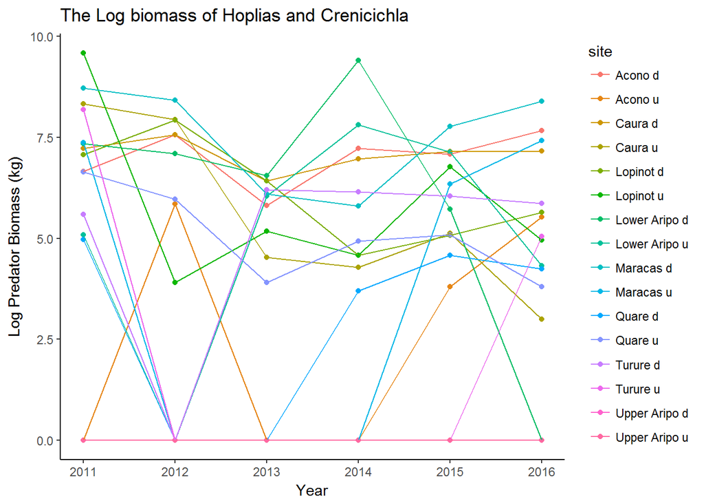

```r
BioPlotL <- ggplot(FishDataTot, aes(x = Year, y = LogBio, col = site, group = site))
BioPlotL + geom_point() +
    geom_line() +
    theme_classic() +
    labs(title="The Log biomass of Hoplias and Crenicichla", y = "Log Predator Biomass (kg)")
```

## Abundance variability in predators initial analysis

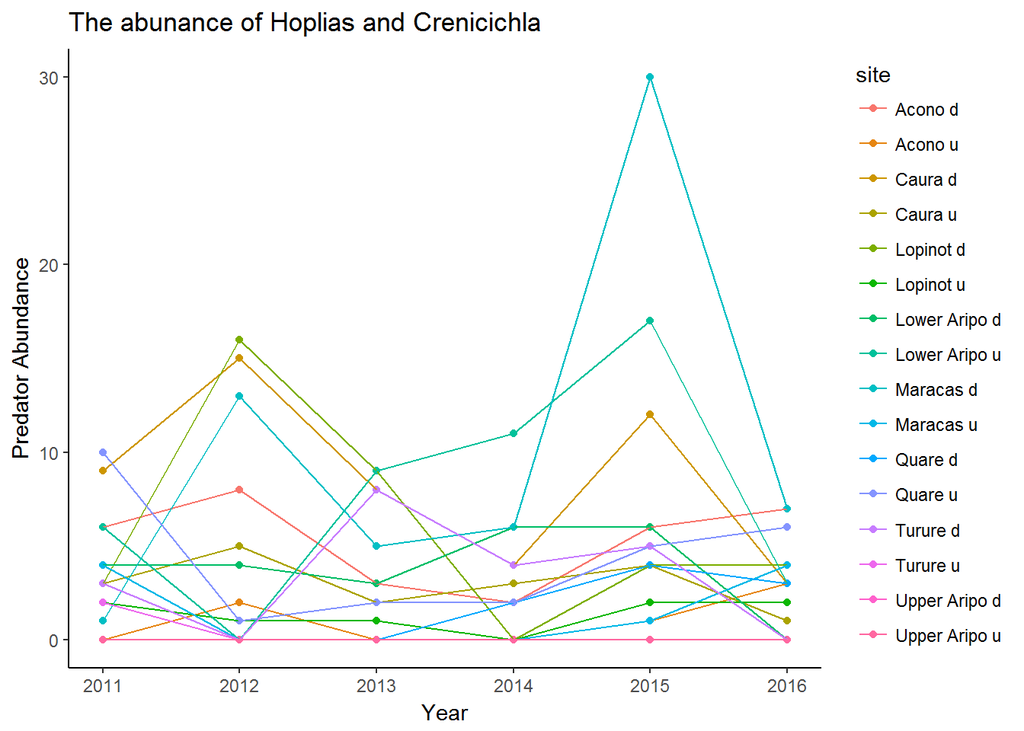

```r
predatorsAbN <- fishData %>%
    filter(species == "Hoplias malabaricus" | species == "Crenicichla frenata") %>%
    group_by(site, Year) %>%
    summarise(AbundanceSum = sum(numbercaught))

predatorsAb <- data.frame(predatorsAbN)
predatorsAb$Year <- as.numeric(predatorsAb$Year)

#add the total site biomass data, just to i can identify sites with no predators
FishDataTotAb <- merge(siteBiomass, predatorsAb, by = c("site" ,"Year"),all=TRUE) # this makes sure i
#know what years had no predators recoreded in
FishDataTotAb$AbundanceSum[is.na(FishDataTotAb$AbundanceSum)] <- 0

#add mean centered year for further analysis
meanYear <-summarise(FishDataTotAb, meanYear = mean(Year))
FishDataTotAb$meanYear <- meanYear[1,]
FishDataTotAb$meanCentredYear <-  FishDataTotAb$Year - FishDataTotAb$meanYear

FishDataTotAb$logAb <- log2(FishDataTotAb$AbundanceSum + 1)

AbPlot <- ggplot(FishDataTotAb, aes(x = Year, y = AbundanceSum, col = site, group = site))
AbPlot + geom_point() +
    geom_line() +
    theme_classic() +
    labs(title="The abunance of Hoplias and Crenicichla", y = "Predator Abundance")
```

Again, I took a look at the coefficients of variation between sites and over time.

```r
#variation between sites
cvSitesa <- FishDataTotAb %>%
  group_by(site) %>%
  summarise(meanSite = mean(AbundanceSum, na.rm=TRUE), sdSite = sd(AbundanceSum, na.rm=TRUE))%>%
  mutate(cvSite = sdSite/meanSite)
cvSitesAb <- data.frame(cvSitesa)
print(cvSitesa)
```

```
## # A tibble: 16 x 4
##             site   meanSite     sdSite    cvSite
##           <fctr>      <dbl>      <dbl>     <dbl>
##  1       Acono d  5.3333333  2.3380904 0.4383919
##  2       Acono u  1.0000000  1.2649111 1.2649111
##  3       Caura d  8.5000000  4.5934736 0.5404087
##  4       Caura u  3.0000000  1.4142136 0.4714045
##  5     Lopinot d  6.0000000  5.6920998 0.9486833
##  6     Lopinot u  1.3333333  0.8164966 0.6123724
##  7 Lower Aripo d  3.8333333  2.2286020 0.5813744
##  8 Lower Aripo u  7.6666667  6.0553007 0.7898218
##  9     Maracas d 10.3333333 10.3858879 1.0050859
## 10     Maracas u  1.5000000  1.9748418 1.3165612
## 11       Quare d  1.8333333  1.6020820 0.8738629
## 12       Quare u  4.3333333  3.3862467 0.7814415
## 13      Turure d  3.3333333  3.0767949 0.9230385
## 14      Turure u  0.3333333  0.8164966 2.4494897
## 15 Upper Aripo d  0.0000000  0.0000000       NaN
## 16 Upper Aripo u  0.0000000  0.0000000       NaN
```

```r
#variation between years
cvYeara <- FishDataTotAb %>%
  group_by(Year) %>%
  summarise(meanYear = mean(AbundanceSum, na.rm=TRUE), sdYear = sd(AbundanceSum, na.rm=TRUE))%>%
  mutate(cvYear = sdYear/meanYear)
cvYearAb <- data.frame(cvYeara)
print(cvYeara)
```

```
## # A tibble: 6 x 4
##    Year meanYear   sdYear    cvYear
##   <dbl>    <dbl>    <dbl>     <dbl>
## 1  2011   3.4375 3.010399 0.8757523
## 2  2012   4.0625 5.755794 1.4168109
## 3  2013   3.1250 3.518996 1.1260787
## 4  2014   2.5000 3.119829 1.2479316
## 5  2015   6.0625 7.835549 1.2924617
## 6  2016   2.6875 2.468974 0.9186881
```

I then ran a mixed model of predatpor abundance against time with site as a random variable to see how much variation could be explained by be differences in sites. In thsi model you can see that quite a lot of the variation from the mean can be attributed to site (roughly 30%). Again sites do not remain either high or low predation.

```r
AbM1 <- lmer(AbundanceSum ~ meanCentredYear + (1|site), data = FishDataTotAb)
summary(AbM1)
```

```
## Linear mixed model fit by REML ['lmerMod']
## Formula: AbundanceSum ~ meanCentredYear + (1 | site)
##    Data: FishDataTotAb
##
## REML criterion at convergence: 553.7
##
## Scaled residuals:
##     Min      1Q  Median      3Q     Max
## -1.9314 -0.4610 -0.2165  0.2734  5.4514
##
## Random effects:
##  Groups   Name        Variance Std.Dev.
##  site     (Intercept)  7.572   2.752
##  Residual             15.233   3.903
## Number of obs: 96, groups:  site, 16
##
## Fixed effects:
##                 Estimate Std. Error t value
## (Intercept)      3.64583    0.79493   4.586
## meanCentredYear  0.04643    0.23324   0.199
##
## Correlation of Fixed Effects:
##             (Intr)
## meanCntrdYr 0.000
```

## relative biomass

i have taken a qick look at proprtional biomass. This looks even more messy than abundance or biomass.

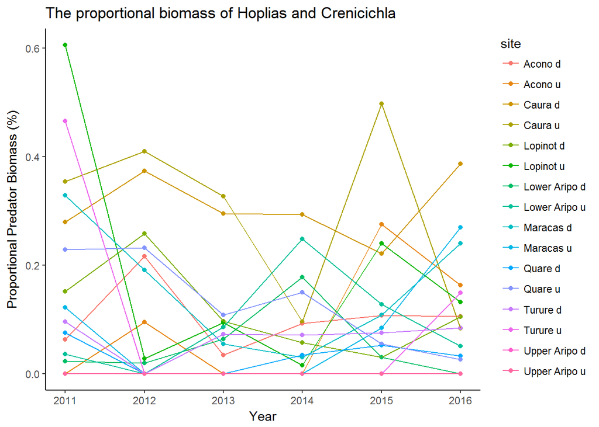

```r
FishDataTot$PropMass <- FishDataTot$BiomassSum / FishDataTot$BiomasSiteSum

PropBioPlot <- ggplot(FishDataTot, aes(x = Year, y = PropMass, col = site, group = site))
PropBioPlot + geom_point() +
    geom_line() +
    theme_classic() +
    labs(title="The proportional biomass of Hoplias and Crenicichla", y = "Proportional Predator Biomass (%)")
```

## Conclusions so far

This is what i have so far: - biomass/abundace/relative biomass all give different estimates of which sites are high abundance - there does not seem to be a clear seperation between high and low predation sites

I still havent decided on the best way to anylise the data. I looked at ANCOVA but this requires the assumption that there is a linear relationship between the covariate (time) and the response variable (predation level). I was thinking perhas an ANOVA or a regression. I did play with a regression, and gound that some sites were coming out as significantly different. I was wondering if you had any other suggestions, as I mostly know how to look for trends, not weigh varience.